# Review Analysis Tests: Review Count & Review Length

Eugenie

12/08/2019

# 1 Load Source File

Data pre-processing is included, where special chars and minimal stop-words are removed.

```r
library(data.table)
## load review data
source("~/Dropbox/Eugenie/scripts/libs.R")
```

Load data.

# 2 Data Processing

Add category data as extra columns. Join on either item_id or child_id.

Drop records before 2012.

Drop records after 2018-10-07 since it’s not a full week.

Drop records with no product category.

Get selected columns for further analysis.

# 3 Analysis Test: Daily Average Review Count

## 3.1 Data Processing

First, we estimate the number of days the product has been available for review by counting the number of days from the first review to the last review.

Get the daily number of reviews per item.

Get mean, variance, and standard deviation of the number of reviews per day by item.

Get the number of daily reviews that is 2 and 3 sd’s away.

Get the item_id and days where the number of daily reviews is above the threshold.

Join results with initial data frame.

## 3.2 Result Analysis

### 3.2.1 Two standard deviations away

| after_ban | review_count.2sd | Freq | Freq_pct |
| --- | --- | --- | --- |
| before | pass | 68632 | 81.49424 |
| before | fail | 15585 | 18.50576 |
| after | pass | 143258 | 74.36218 |
| after | fail | 49391 | 25.63782 |

| incentivized | review_count.2sd | Freq | Freq_pct |
| --- | --- | --- | --- |
| incentivized | pass | 27 | 90.00000 |
| incentivized | fail | 3 | 10.00000 |
| non-incentivized | pass | 211863 | 76.53015 |
| non-incentivized | fail | 64973 | 23.46985 |

Mean review rating for over vs. under daily threshold for the number of reviews.

| Group.1 | x |
| --- | --- |
| pass | 4.020024 |
| fail | 4.219250 |

Review distribution between groups.

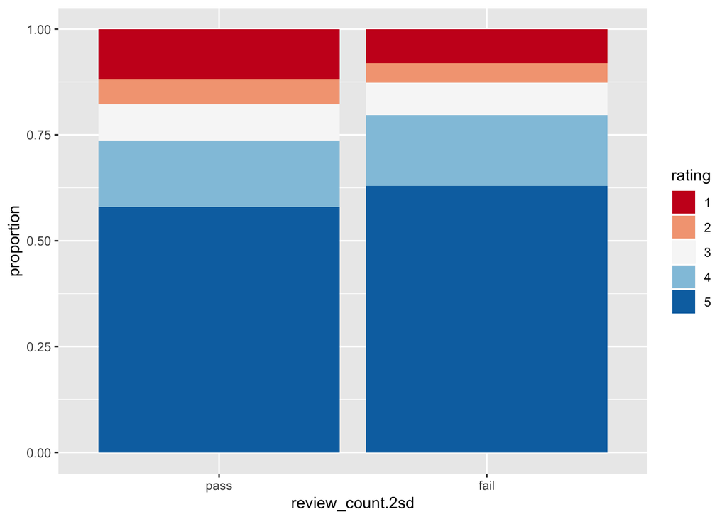

Percentage of reviews that is over daily threshold by item.

```
##    Min. 1st Qu.  Median    Mean 3rd Qu.    Max.
##   4.469  23.025  32.960  47.136 100.000 100.000
```

Linear Regression with Fixed Effect on Item ID

**Linear Regression with Fixed Effect: Daily Review Count**

|  | *Dependent variable:* |
| --- | --- |
|  | rating |
| review_count.2sdfail | 0.208*** |
|  | (0.006) |
| Observations | 276,866 |
| R<sup>2</sup> | 0.004 |
| Adjusted R<sup>2</sup> | 0.004 |
| F Statistic | 1,145.743*** (df = 1; 276793) |
| *Note:* | p<0.1; p<0.05; p<0.01 |

From the result of the linear fixed effect modelling, the null hypothesis of the independency of products is rejected.

### 3.2.2 Three standard deviations away

| after_ban | review_count.3sd | Freq | Freq_pct |
| --- | --- | --- | --- |
| before | pass | 75582 | 89.74673 |
| before | fail | 8635 | 10.25327 |
| after | pass | 160812 | 83.47409 |
| after | fail | 31837 | 16.52591 |

| incentivized | review_count.3sd | Freq | Freq_pct |
| --- | --- | --- | --- |
| incentivized | pass | 28 | 93.333333 |
| incentivized | fail | 2 | 6.666667 |
| non-incentivized | pass | 236366 | 85.381236 |
| non-incentivized | fail | 40470 | 14.618764 |

Mean review rating for over vs. under daily threshold for the number of reviews.

| Group.1 | x |
| --- | --- |
| pass | 4.035783 |
| fail | 4.247826 |

Review distribution between groups.

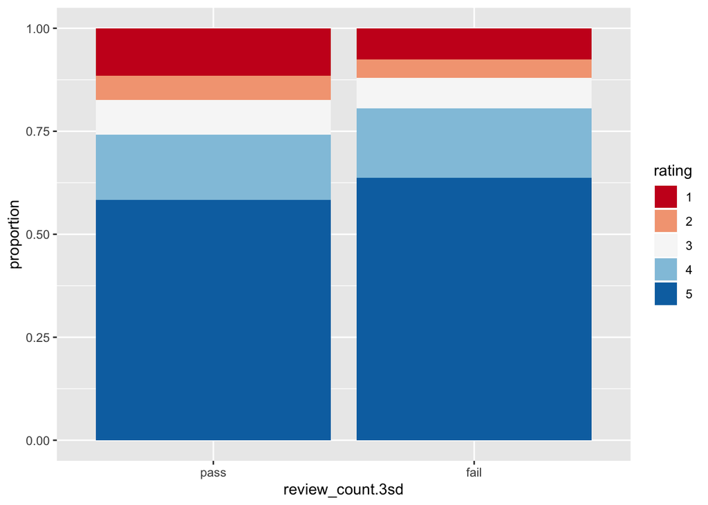

Percentage of reviews that is over daily threshold by item.

```
##    Min. 1st Qu.  Median    Mean 3rd Qu.    Max.
##   3.021  10.957  15.590  27.563  21.952 100.000
```

Linear Regression with Fixed Effect on Item ID

**Linear Regression with Fixed Effect: Daily Review Count**

|  | *Dependent variable:* |
| --- | --- |
|  | rating |
| review_count.3sdfail | 0.203*** |
|  | (0.007) |
| Observations | 276,866 |
| R<sup>2</sup> | 0.003 |
| Adjusted R<sup>2</sup> | 0.002 |
| F Statistic | 760.194*** (df = 1; 276793) |
| *Note:* | p<0.1; p<0.05; p<0.01 |

From the result of the linear fixed effect modelling, the null hypothesis of the independency of products is rejected.

# 4 Analysis Test: Average Review Length

Once we have the word count distribution of the product and the expected distribution of the category we compare the two distributions and identify product word count groups that are higher in concentration than we’d expect to see.

## 4.1 Data Processing

Bin the review length.

Get the length of reviews per product category.

By product category, calculate mean, variance, and standard deviation.

Get the number of daily reviews that is 2 and 3 sd’s away.

Get the item_id and days where the number of daily reviews is above the threshold.

Join results with initial data frame.

## 4.2 Result Analysis

### 4.2.1 Two standard deviations away

| after_ban | word_count.2sd | Freq | Freq_pct |
| --- | --- | --- | --- |
| before | pass | 84217 | 100.0000000 |
| before | fail | 0 | 0.0000000 |
| after | pass | 192283 | 99.8100172 |
| after | fail | 366 | 0.1899828 |

| incentivized | word_count.2sd | Freq | Freq_pct |
| --- | --- | --- | --- |
| incentivized | pass | 30 | 100.0000000 |
| incentivized | fail | 0 | 0.0000000 |
| non-incentivized | pass | 276470 | 99.8677918 |
| non-incentivized | fail | 366 | 0.1322082 |

Mean review rating for over vs. under length threshold for the number of reviews.

| Group.1 | x |
| --- | --- |
| pass | 4.067562 |
| fail | 3.475410 |

Review distribution between groups.

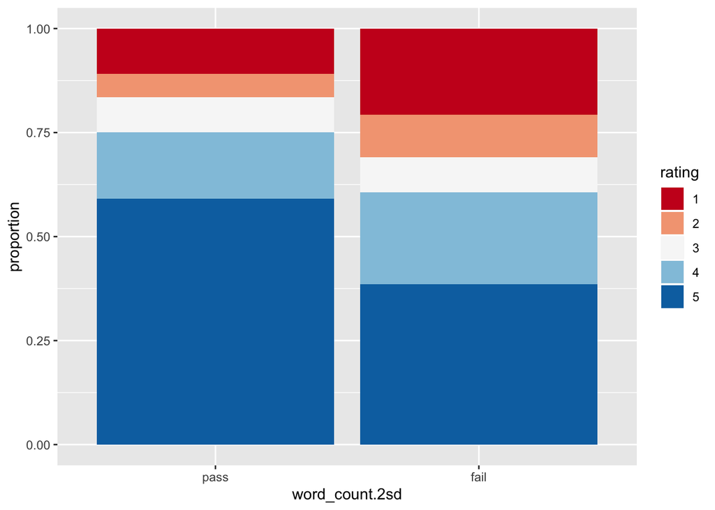

Percentage of reviews that is over length threshold by item.

```
##    Min. 1st Qu.  Median    Mean 3rd Qu.    Max.
##    0.00    0.00    0.00   11.09    9.12  100.00
```

#### 4.2.1.1 Linear Regression with Fixed Effect on Item ID

**Linear Regression with Fixed Effect: Review Word Count**

|  | *Dependent variable:* |
| --- | --- |
|  | rating |
| word_count.2sdfail | -0.370*** |
|  | (0.080) |
| Observations | 276,866 |
| R<sup>2</sup> | 0.0001 |
| Adjusted R<sup>2</sup> | -0.0002 |
| F Statistic | 21.528*** (df = 1; 276793) |
| *Note:* | p<0.1; p<0.05; p<0.01 |

From the result of the linear fixed effect modelling, the null hypothesis of the independency of products is rejected.

#### 4.2.1.2 Graphs

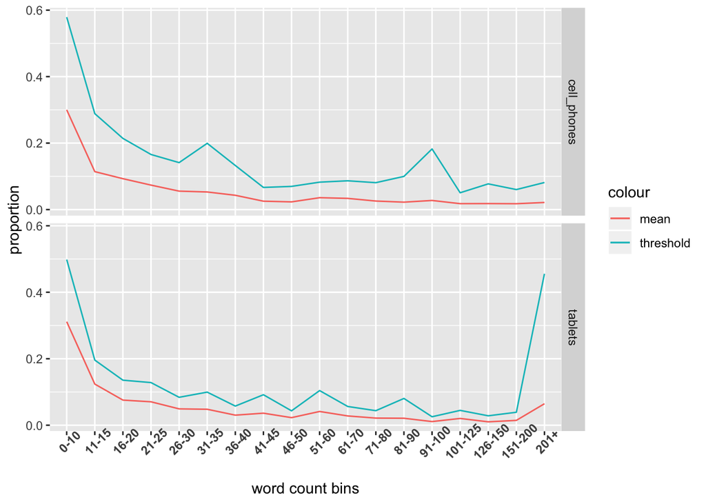

### 4.2.2 Three standard deviations away

| after_ban | word_count.3sd | Freq | Freq_pct |
| --- | --- | --- | --- |
| before | pass | 84217 | 100.0000000 |
| before | fail | 0 | 0.0000000 |
| after | pass | 192614 | 99.9818322 |
| after | fail | 35 | 0.0181678 |

| incentivized | word_count.3sd | Freq | Freq_pct |
| --- | --- | --- | --- |
| incentivized | pass | 30 | 100.0000000 |
| incentivized | fail | 0 | 0.0000000 |
| non-incentivized | pass | 276801 | 99.9873571 |
| non-incentivized | fail | 35 | 0.0126429 |

Mean review rating for over vs. under length threshold for the number of reviews.

| Group.1 | x |
| --- | --- |
| pass | 4.066911 |
| fail | 3.028571 |

Review distribution between groups.

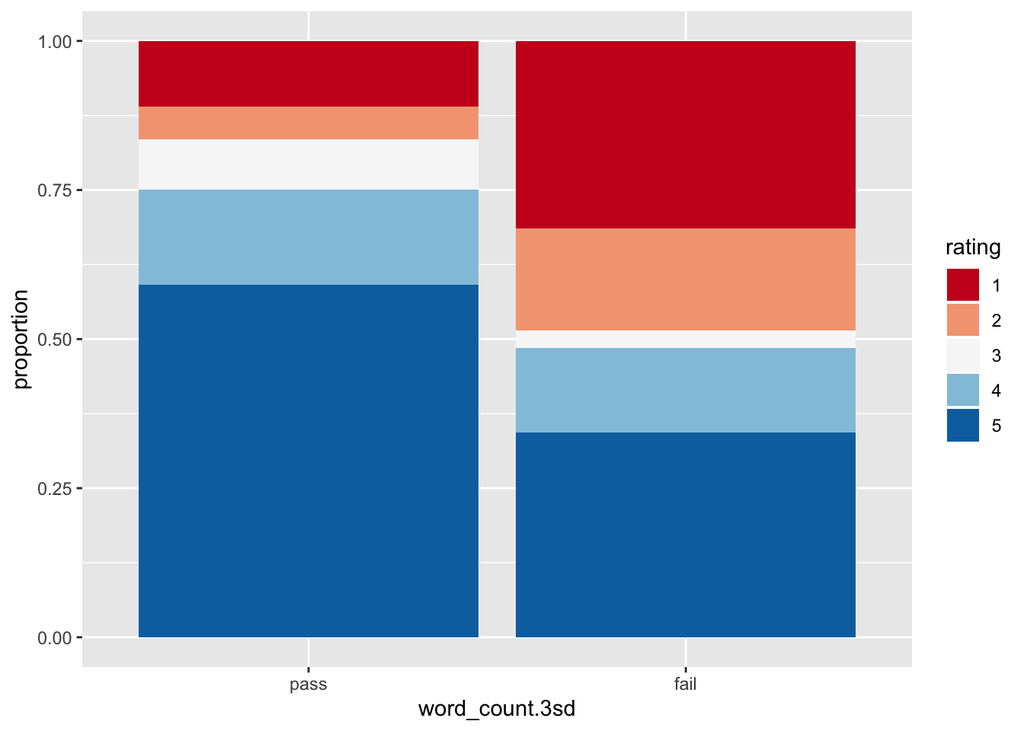

Percentage of reviews that is over length threshold by item.

```
##    Min. 1st Qu.  Median    Mean 3rd Qu.    Max.
##   0.000   0.000   0.000   7.549   0.000 100.000
```

#### 4.2.2.1 Linear Regression with Fixed Effect on Item ID

**Linear Regression with Fixed Effect: Review Word Count**

|  | *Dependent variable:* |
| --- | --- |
|  | rating |
| word_count.3sdfail | -1.202*** |
|  | (0.350) |
| Observations | 276,866 |
| R<sup>2</sup> | 0.00004 |
| Adjusted R<sup>2</sup> | -0.0002 |
| F Statistic | 11.793*** (df = 1; 276793) |
| *Note:* | p<0.1; p<0.05; p<0.01 |

From the result of the linear fixed effect modelling, the null hypothesis of the independency of products is rejected.

#### 4.2.2.2 Graphs

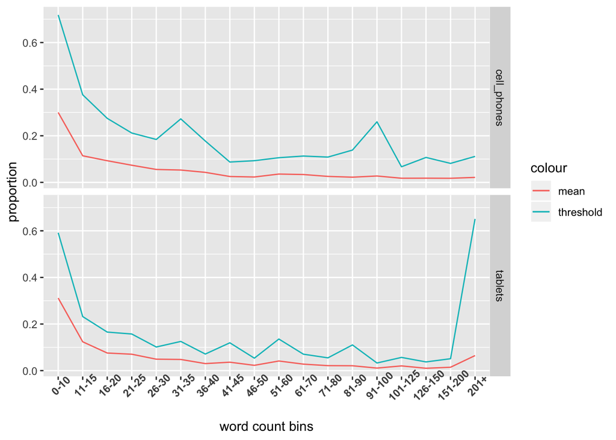

# 5 Analysis on Reviews Fail Both Tests

## 5.1 The number/percentage of reviews fail both/single test(s)

### 5.1.1 Two SD

| .id | review_count.2sd | word_count.2sd | Freq | Freq_pct |
| --- | --- | --- | --- | --- |
| NA | pass | pass | 211625 | 76.4358932 |
| NA | fail | pass | 64875 | 23.4319129 |
| NA | pass | fail | 265 | 0.0957142 |
| NA | fail | fail | 101 | 0.0364797 |

### 5.1.2 Three SD

| .id | review_count.3sd | word_count.3sd | Freq | Freq_pct |
| --- | --- | --- | --- | --- |
| NA | pass | pass | 236391 | 85.3810146 |
| NA | fail | pass | 40440 | 14.6063439 |
| NA | pass | fail | 3 | 0.0010836 |
| NA | fail | fail | 32 | 0.0115579 |

## 5.2 After the ban date

### 5.2.1 Two SD

| after_ban | review_count.2sd | word_count.2sd | Freq | Freq_pct |
| --- | --- | --- | --- | --- |
| before | pass | pass | 68632 | 81.4942351 |
| before | fail | pass | 15585 | 18.5057649 |
| before | pass | fail | 0 | 0.0000000 |
| before | fail | fail | 0 | 0.0000000 |
| after | pass | pass | 142993 | 74.2246261 |
| after | fail | pass | 49290 | 25.5853910 |
| after | pass | fail | 265 | 0.1375559 |
| after | fail | fail | 101 | 0.0524270 |

### 5.2.2 Three SD

| after_ban | review_count.3sd | word_count.3sd | Freq | Freq_pct |
| --- | --- | --- | --- | --- |
| before | pass | pass | 75582 | 89.7467257 |
| before | fail | pass | 8635 | 10.2532743 |
| before | pass | fail | 0 | 0.0000000 |
| before | fail | fail | 0 | 0.0000000 |
| after | pass | pass | 160809 | 83.4725329 |
| after | fail | pass | 31805 | 16.5092993 |
| after | pass | fail | 3 | 0.0015572 |
| after | fail | fail | 32 | 0.0166105 |

## 5.3 How many are incentivized?

### 5.3.1 Two SD

| incentivized | review_count.2sd | word_count.2sd | Freq | Freq_pct |
| --- | --- | --- | --- | --- |
| incentivized | pass | pass | 27 | 90.0000000 |
| incentivized | fail | pass | 3 | 10.0000000 |
| incentivized | pass | fail | 0 | 0.0000000 |
| incentivized | fail | fail | 0 | 0.0000000 |
| non-incentivized | pass | pass | 211598 | 76.4344233 |
| non-incentivized | fail | pass | 64872 | 23.4333685 |
| non-incentivized | pass | fail | 265 | 0.0957245 |
| non-incentivized | fail | fail | 101 | 0.0364837 |

### 5.3.2 Three SD

| incentivized | review_count.3sd | word_count.3sd | Freq | Freq_pct |
| --- | --- | --- | --- | --- |
| incentivized | pass | pass | 28 | 93.3333333 |
| incentivized | fail | pass | 2 | 6.6666667 |
| incentivized | pass | fail | 0 | 0.0000000 |
| incentivized | fail | fail | 0 | 0.0000000 |
| non-incentivized | pass | pass | 236363 | 85.3801529 |
| non-incentivized | fail | pass | 40438 | 14.6072043 |
| non-incentivized | pass | fail | 3 | 0.0010837 |
| non-incentivized | fail | fail | 32 | 0.0115592 |

# 6 Other Info

Percentage/count of reviews for products didn’t come out until 2016-10-03 (after ban date).

| .id | Var1 | Freq | Freq_pct |
| --- | --- | --- | --- |
| NA | before | 276866 | 100 |
| NA | after | 0 | 0 |